# Visualising Brexit Votes with Leaflet and Cartogram

Xinye Li

16 March 2017

On the eve of triggering the Article 50, I think it’s semi-fitting to revisit the Brexit results.

### What’s the topic?

The [2016 Brexit catastrophy](https://en.wikipedia.org/wiki/United_Kingdom_European_Union_membership_referendum,_2016) (a.k.a. United Kingdom European Union membership referendum, 2016), specifically the visualisation of the results on a map, with each area (Local Authority in this case) proportioned by the number of votes, in the hope that it could capture the variety of sentiment on the topic across the country. The use of Cartogram should be an obvious choice in distorting the map areas, and while there have been plenty visualisation of such kind for General Elections, it has not been done for the Brexit.

### Is there anything new I’m getting?

After [so](http://www.bbc.co.uk/news/uk-politics-36616028) [much](https://medium.com/@jakeybob/brexit-maps-d70caab7315e#.k8mztsqz1) [has](http://www.telegraph.co.uk/news/0/leave-or-remain-eu-referendum-results-and-live-maps/) [been](http://www.thepoke.co.uk/2017/01/13/post-brexit-map-uk-accurate-funny/) done on visualising Brexit, I thought I’d combine the following to create something with in R:

- **Shapefile** - a ubiquitous geospatial vector data format. I shall demonstrate the ease of manipulating the file with R.
- **Cartogram** - a mapping distortion technique for representing geographic data in a striking way.
- **Hexagon** - a type of mapping distortion focused on representing geographic units with a uniform area size.
- **Leaflet** - a modern and popular Javascript package for visualsation in the browser.

### What are the benefits if any?

- **Hopefully I can bring the UK Hexagon Shapefiles to more people’s attention**. After some searching I have only found a couple of sources for UK hexagon maps ([Parliamentary Constituencies](http://www.arcgis.com/home/item.html?id=15baaa6fecd54aa4b7250780b6534682) and [Local Authorities](http://www.arcgis.com/home/item.html?id=593037bc399e460bb7c6c631ceff67b4) along with a [tool](https://www.arcgis.com/home/item.html?id=d348614c97264ae19b0311019a5f2276) to create them) published by Esri (while there are plenty for the US, e.g. the [`tilegramsR`](https://rpubs.com/bhaskarvk/tilegramsR) package gives you several beautiful options). The votes data is aggregated to the Local Authority level, so the corresponding shapefile shall be used.
- **Hexagon maps are great for simplifying complicated geo-shapes while preserving all relevant information**. Cartogram is a great way to emphasise data features on a map. However in the case of the UK, there are close to 400 local authorities, plotting them all on the with their distorted irregular shapes would not be so visually pleasant or informative. When the starting point is a hexagon cartogram, however, the features are laid out in a regular grid, after distortion it is much easier on the eyes.
- **Leaflet is great for investigating data in detail**. Faced with a map of a crowded bunch of colour shapes, one’s first instinct (especially if you are familiar with the UK geography) would be to work out which shape respresents which Local Authority, and the only way is of course an interactive map that can show you the name and the vote counts of a shape.

### Get down to the business

#### The votes data

The data source is [The Electoral Commssion](http://www.electoralcommission.org.uk/find-information-by-subject/elections-and-referendums/past-elections-and-referendums/eu-referendum/electorate-and-count-information) and the CSV can be downloaded directly from [here](http://www.electoralcommission.org.uk/__data/assets/file/0014/212135/EU-referendum-result-data.csv).

```r
csv_url <- 'http://www.electoralcommission.org.uk/__data/assets/file/0014/212135/EU-referendum-result-data.csv'

# For reproducibility the CSV is also downloaded in the data/ folder
# download.file(url = csv_url, destfile = paste0('./data/', regmatches(csv_url, regexpr('[^/]+$', csv_url))))

raw_votes <- read.csv(csv_url, stringsAsFactors = F)

# Create names_votes to match against the shape file later
names_votes <- raw_votes$Area
```

So there are 382 Local Authorities. Let’s get the appropriate shapefile, and check out what data is already attached:

#### The hexagon shapefile

```r
pacman::p_load(rgdal, dplyr)
la_shp <- readOGR(dsn = './data/GB_Hex_Cartogram_LAs', layer = "GB_Hex_Cartogram_LAs")
names_shp <- as.character(la_shp$LAD12NM) # for matching the CSV file later
head(la_shp@data)
```

```
##   OBJECTID   LAD12CD         LAD12NM Shape_Leng Shape_Area
## 0        1 E07000205 Suffolk Coastal   127685.1 1176601978
## 1        2 E07000202         Ipswich   127686.2 1176622756
## 2        3 E07000076        Tendring   127685.7 1176613311
## 3        4 E07000145  Great Yarmouth   127685.8 1176614926
## 4        5 E07000206         Waveney   127685.4 1176607876
## 5        6 E07000203     Mid Suffolk   127686.5 1176628446
```

Let’s plot it against an actual map to get a sense of it. To do that let’s project it to WGS84 (`EPSG:4326`) measured in degrees of latitude / longitude, which also allows to set up the bouding box easier.

*Note: using ggplot to overlay polygons on a map requires turning the shapefile into a data frame by using `broom::tidy()`. After running the function if you encounter this error `Error: isTRUE(gpclibPermitStatus()) is not TRUE` on Windows, make sure Rtools is installed, then install package `gpclib` using `install.packages('gpclib', type = 'source')`. To verify everything is fine, run `gpclibPermitStatus()` and `gpclibPermit()`, if both return `True` then you are all set.*

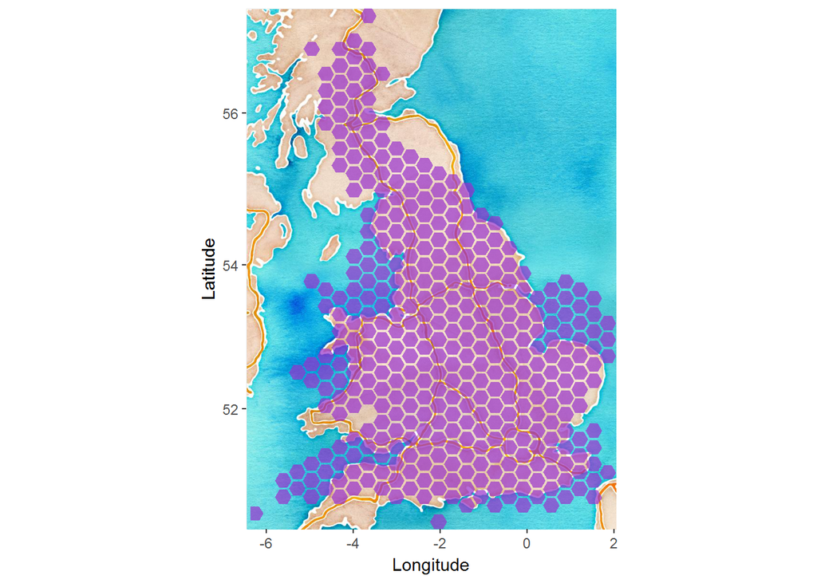

```r
pacman::p_load(broom, ggplot2, ggmap)

# Re-project the map into the WGS (World Geodetic System, i.e. longitudes and latitudes)
la_84 <- spTransform(la_shp, CRS('+init=epsg:4326'))
la_84_df <- la_84 %>% tidy(region = "LAD12NM")
b <- bbox(la_84)
basemap <- ggmap(
  get_map(location = b,
          source = "stamen",
          maptype = "watercolor",
          crop = T))
basemap + geom_polygon(
  data = la_84_df,
  aes(x = long, y = lat, group = group),
  fill = 'darkorchid',
  alpha = 0.7) + xlab('Longitude') + ylab('Latitude')
```

So the hexagon map is roughly based on the actual coordicates of the features.

But wait, the Local Authority shapefile has a flaw - it is missing Northern Ireland and Gibraltar, confirmed by comparing the names from the CSV and the shapefile (The Vale of Glamorgan also has different names in the two files, let’s deal with that later)

```r
setdiff(names_votes, names_shp)
```

```
## [1] "Northern Ireland"  "Gibraltar"         "Vale of Glamorgan"
```

```r
setdiff(names_shp, names_votes)
```

```
## [1] "The Vale of Glamorgan"
```

Let’s create them!